# Projekt 1 - Feature engineering i wstępne testowanie modeli

Michał Stawikowski, Adam Rydelek, Witold Merkel

02 - 04 - 2019

# 1 Wprowadzenie

Celem tego raportu jest przedstawienie jakich zmian dokonaliśmy w wyjściowej ramce danych w ramach inżynierii danych oraz zaprezentowanie wyników kilkunastu modeli jeszcze bez strojenia hiperparametrów. Na początku omówimy wpływ wybierania i dodawania kolumn na skuteczność klasyfikacji, później spróbujemy wybrać najlepsze w naszym przypadku kodowanie zmiennych kategorycznych. Na koniec przetestujemy kilkanaście klasyfikatorów na obronionej już ramce danych i wybierzemy kilka najlepszych.

# 2 Nowe zmienne

|  | custody_count | custody_sum | jail_time | bust_date |
| --- | --- | --- | --- | --- |
| 1 | 1 | 23 | 1 | 2013-04-23 |
| 2 | 1 | 2 | 2 | 2013-11-03 |
| 3 | 2 | 565 | 55 | 2013-11-20 |
| 5 | 1 | 8 | 118 | 2014-11-24 |
| 6 | 1 | 32 | 0 | 2013-12-24 |
| 7 | 3 | 61 | 1 | 2013-09-16 |
| 10 | 3 | 15 | 1 | 2013-09-20 |
| 13 | 1 | 1 | 1 | 2013-02-06 |
| 14 | 1 | 3 | 3 | 2014-11-04 |
| 15 | 1 | 2 | 11 | 2013-10-08 |

[output cut: 9990 more lines]

Nowo dodanymi kolumnami są:

- `custody_count` - opisująca ilość odsiadek w areszcie
- `custody_sum` - zawierająca ilość dni spędzonych w areszcie
- `jail_time` - mówiąca nam ile dni przestępca spędził w więzioniu
- `bust_date` - zmienna stworzona przez scalenie dwóch bardzo niekompletnych kolumn w jedną, dzięki czemu uzyskaliśmy przybliżoną datę zatrzymania przestępcy

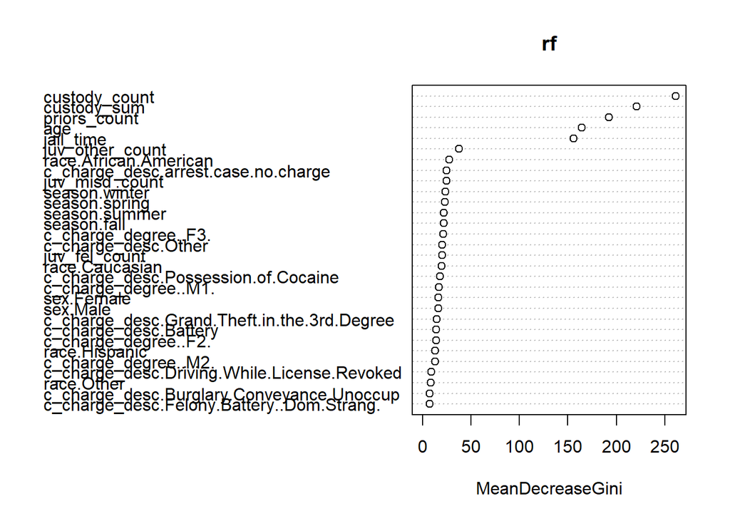

```r
library(randomForest)
varImpPlot(rf)
```

Jak widać nowo dodane zmienne plasują się w czołówce jeśli chodzi o istotność.

# 3 Grupowanie w kategorie

## 3.1 Dokładna data a sezon

```r
r$aggr
```

```
## acc.test.mean auc.test.mean tnr.test.mean tpr.test.mean ppv.test.mean
##     0.7353602     0.7349978     0.4370159     0.8863956     0.7566835
##  f1.test.mean
##     0.8163326
```

Tak prezentuje się wynik kroswalidacji z dokładnymi danymi.

```r
r2$aggr
```

```
## acc.test.mean auc.test.mean tnr.test.mean tpr.test.mean ppv.test.mean
##     0.7363277     0.7288624     0.4363135     0.8884176     0.7568580
##  f1.test.mean
##     0.8172630
```

A tak z uproszczoną kategorią `sezon`. Widać drobną poprawę dla danych z pogrupowaną datą. W dalszych rozważaniach będziemy poługiwać sie zmienną uproszczoną.

## 3.2 Dokładny wiek i kategoria wiekowa

```r
r3$aggr
```

```
## acc.test.mean auc.test.mean tnr.test.mean tpr.test.mean ppv.test.mean
##     0.7371992     0.7308479     0.4320540     0.8917997     0.7561264
##  f1.test.mean
##     0.8183477
```

Wyniki dla szczegółowej zmiennej.

```r
r4$aggr
```

```
## acc.test.mean auc.test.mean tnr.test.mean tpr.test.mean ppv.test.mean
##     0.7364246     0.7245514     0.4351060     0.8890310     0.7565666
##  f1.test.mean
##     0.8174272
```

# 4 Porównanie kodowanie zmiennych

## 4.1 Impact encoding

Najpierw sprawdzimy jak `impact encoding` wpłynie na jakoś predykcji.

```r
dataimpact <- select(datay, -c(first,last,dob,age_cat,c_jail_in,c_jail_out,month,year))
yq <- as.yearqtr(as.yearmon(dataimpact$bust_date, "%m/%d/%Y") + 1/12)
dataimpact$season <- factor(format(yq, "%q"), levels = 1:4,
                            labels = c("winter", "spring", "summer", "fall"))

pomoc <- ifelse(!is.na(dataimpact$season), dataimpact$season, "other")
dataimpact$season <- factor(pomoc, levels = c(1:4, "other"),
                            labels = c("winter", "spring", "summer", "fall", "other"))


spec = c(train = .6, test = .2, validate = .2)
g = sample(cut(
  seq(nrow(dataimpact)),
  nrow(dataimpact)*cumsum(c(0,spec)),
  labels = names(spec)
))

res <- split(dataimpact, g)
train <- res$train
calibration <- res$validate
test <- res$test
pruneSig <- 1/ncol(train)

library(vtreat)
treatments <- designTreatmentsN(calibration, varlist=colnames(train), outcome="is_recid", verbose=FALSE)
scoreFrame <- treatments$scoreFrame
vars <- scoreFrame$varName[(scoreFrame$code %in% c("catN", "clean"))]
dTrainTreated <- prepare(treatments,train,pruneSig=pruneSig, varRestriction = vars)
dTrainTreated$is_recid <- factor(dTrainTreated$is_recid)
classif_task_t <- makeClassifTask(id = "task", data = dTrainTreated, target = "is_recid")
classif_lrn_t <- makeLearner("classif.gbm", predict.type = "prob")
dTestTreated <- prepare(treatments,test,
                        pruneSig=pruneSig, varRestriction = vars)
model2 <- mlr::train(classif_lrn_t, classif_task_t)
```

```
## Distribution not specified, assuming bernoulli ...
```

```r
predict2 <- predict(model2, newdata = dTestTreated, type='response')
confusionMatrix(factor(predict2$data$response), factor(dTestTreated$is_recid))
```

```
## Confusion Matrix and Statistics
##
##           Reference
## Prediction    0    1
##          0 1276  397
##          1  105  288
##
##                Accuracy : 0.757
##                  95% CI : (0.7379, 0.7754)
##     No Information Rate : 0.6684
##     P-Value [Acc > NIR] : < 2.2e-16
##
##                   Kappa : 0.3859
##  Mcnemar's Test P-Value : < 2.2e-16
##
##             Sensitivity : 0.9240
##             Specificity : 0.4204
##          Pos Pred Value : 0.7627
##          Neg Pred Value : 0.7328
##              Prevalence : 0.6684
##          Detection Rate : 0.6176
##    Detection Prevalence : 0.8098
##       Balanced Accuracy : 0.6722
##
##        'Positive' Class : 0
##
```

Widzimy, że lekko poprawia to jakość predykcji.

## 4.2 OneHot z zrównaniem rzadkich poziomów

Sprawdźmy teraz co osiągniemy poprzez `OneHot encoding` i łączenie rzadkich poziomów. Zdecydowaliśmy się na połączenie poziomów w `ChargeDescription`, rozważymy trzy liczby pozostawionych poziomów: **30**, **75**, **125**.

### 4.2.1 30 pozostawioych poziomów

```r
datarare <- final
datarare$c_charge_desc <- fct_lump(datarare$c_charge_desc, 30)
datarare <- select(datarare, -c(month,year,is_recid,first,last,dob,age_cat,c_jail_in,c_jail_out,bust_date))
dmyT <- dummyVars(" ~ .", data = datarare)
dmydata <- data.frame(predict(dmyT, newdata = datarare))
dmydata$is_recid <- final$is_recid
res <- split(dmydata, g)
trainOne <- res$train
calibrationOne <- res$validate
testOne <- res$test
trainOne$is_recid <- factor(trainOne$is_recid)
testOne$is_recid <- factor(testOne$is_recid)

#######
trainOne <- na.omit(trainOne)
#######

classif_task_t <- makeClassifTask(id = "task", data = trainOne, target = "is_recid")
classif_lrn_t <- makeLearner("classif.gbm", predict.type = "prob")
model2 <- mlr::train(classif_lrn_t, classif_task_t)
```

```
## Distribution not specified, assuming bernoulli ...
```

```r
predict2 <- predict(model2, newdata = testOne, type='response')
confusionMatrix(factor(predict2$data$response), factor(dTestTreated$is_recid))
```

```
## Confusion Matrix and Statistics
##
##           Reference
## Prediction    0    1
##          0 1276  399
##          1  105  286
##
##                Accuracy : 0.7561
##                  95% CI : (0.7369, 0.7744)
##     No Information Rate : 0.6684
##     P-Value [Acc > NIR] : < 2.2e-16
##
##                   Kappa : 0.3829
##  Mcnemar's Test P-Value : < 2.2e-16
##
##             Sensitivity : 0.9240
##             Specificity : 0.4175
##          Pos Pred Value : 0.7618
##          Neg Pred Value : 0.7315
##              Prevalence : 0.6684
##          Detection Rate : 0.6176
##    Detection Prevalence : 0.8107
##       Balanced Accuracy : 0.6707
##
##        'Positive' Class : 0
##
```

Widizmy, że polepszyło to `accuracy`, w porównaniu z “gołymi” danymi, ale pogrszyło względem `impact encodingu` sprawdźmy zatem jak zmieni to zwiększenie liczby pozostawionych modeli.

### 4.2.2 75 pozostawioych poziomów

```r
datarare <- final
datarare$c_charge_desc <- fct_lump(datarare$c_charge_desc, 75)
datarare <- select(datarare, -c(month,year,is_recid,first,last,dob,age_cat,c_jail_in,c_jail_out,bust_date))
dmyT <- dummyVars(" ~ .", data = datarare)
dmydata <- data.frame(predict(dmyT, newdata = datarare))
dmydata$is_recid <- final$is_recid
res <- split(dmydata, g)
trainOne <- res$train
calibrationOne <- res$validate
testOne <- res$test
trainOne$is_recid <- factor(trainOne$is_recid)
testOne$is_recid <- factor(testOne$is_recid)

#######
trainOne <- na.omit(trainOne)
#######

classif_task_t <- makeClassifTask(id = "task", data = trainOne, target = "is_recid")
classif_lrn_t <- makeLearner("classif.gbm", predict.type = "prob")
model2 <- mlr::train(classif_lrn_t, classif_task_t)
```

```
## Distribution not specified, assuming bernoulli ...
```

```r
predict2 <- predict(model2, newdata = testOne, type='response')
confusionMatrix(factor(predict2$data$response), factor(dTestTreated$is_recid))
```

```
## Confusion Matrix and Statistics
##
##           Reference
## Prediction    0    1
##          0 1277  390
##          1  104  295
##
##                Accuracy : 0.7609
##                  95% CI : (0.7419, 0.7791)
##     No Information Rate : 0.6684
##     P-Value [Acc > NIR] : < 2.2e-16
##
##                   Kappa : 0.3971
##  Mcnemar's Test P-Value : < 2.2e-16
##
##             Sensitivity : 0.9247
##             Specificity : 0.4307
##          Pos Pred Value : 0.7660
##          Neg Pred Value : 0.7393
##              Prevalence : 0.6684
##          Detection Rate : 0.6181
##    Detection Prevalence : 0.8069
##       Balanced Accuracy : 0.6777
##
##        'Positive' Class : 0
##
```

Otrzymujemy już wynik lepszy niż ten w przypadku `impact encodingu`, sprawdźmy zatem czy jak zwiększymy liczbę poziomów to czy ponownie zwiększy się `accuracy`.

### 4.2.3 125 pozostawioych poziomów

```r
datarare <- final
datarare$c_charge_desc <- fct_lump(datarare$c_charge_desc, 125)
datarare <- select(datarare, -c(month,year,is_recid,first,last,dob,age_cat,c_jail_in,c_jail_out,bust_date))
dmyT <- dummyVars(" ~ .", data = datarare)
dmydata <- data.frame(predict(dmyT, newdata = datarare))
dmydata$is_recid <- final$is_recid
res <- split(dmydata, g)
trainOne <- res$train
calibrationOne <- res$validate
testOne <- res$test
trainOne$is_recid <- factor(trainOne$is_recid)
testOne$is_recid <- factor(testOne$is_recid)

#######
trainOne <- na.omit(trainOne)
#######

classif_task_t <- makeClassifTask(id = "task", data = trainOne, target = "is_recid")
classif_lrn_t <- makeLearner("classif.gbm", predict.type = "prob")
model2 <- mlr::train(classif_lrn_t, classif_task_t)
```

```
## Distribution not specified, assuming bernoulli ...
```

```r
predict2 <- predict(model2, newdata = testOne, type='response')
confusionMatrix(factor(predict2$data$response), factor(dTestTreated$is_recid))
```

```
## Confusion Matrix and Statistics
##
##           Reference
## Prediction    0    1
##          0 1278  401
##          1  103  284
##
##                Accuracy : 0.7561
##                  95% CI : (0.7369, 0.7744)
##     No Information Rate : 0.6684
##     P-Value [Acc > NIR] : < 2.2e-16
##
##                   Kappa : 0.3819
##  Mcnemar's Test P-Value : < 2.2e-16
##
##             Sensitivity : 0.9254
##             Specificity : 0.4146
##          Pos Pred Value : 0.7612
##          Neg Pred Value : 0.7339
##              Prevalence : 0.6684
##          Detection Rate : 0.6186
##    Detection Prevalence : 0.8127
##       Balanced Accuracy : 0.6700
##
##        'Positive' Class : 0
##
```

Tym razem `accuracy` ponownie spadło, zatem widzimy, że im więcej poziomów to nie koniecznie lepiej.

# 5 Standaryzacja

W tej sekcji pokażemy co się dzieje z dokładnością, jeżeli złączymy rzadkie poziomy (poniżej 7.5% występowania) oraz zastosujemy standaryzację na odpowiednich do tego zmiennych. Tutaj będziemy rozważać standaryzację, która odejmuję od obserwacji średnią wszystkich obserwacji, a wynik dzieli przez odchylenie standardowe.

```r
performance(predict(model_szybko, newdata = (testC %>>% powtorz)),
            measures = list(auc, acc))
```

```
##       auc       acc
## 0.7721506 0.7477419
```

Widzimy, że wynik nie poprawił się znacząco, wręcz pogorszyły.

# 6 Skalowanie na przedział [0;1]

W tej sekcji pokażemy co się dzieje z dokładnością, jeżeli złączymy rzadkie poziomy (poniżej 7.5% występowania) oraz odpowiednie do tego zmienne przeskalujemy na odcinek [0;1].

```r
performance(predict(model_szybko, newdata = (testC %>>% powtorz)),
            measures = list(auc, acc))
```

```
##       auc       acc
## 0.7671277 0.7412903
```

Widać, że to też nie poprawia wyniku względem tego co otrzymaliśmy wcześniej.

# 7 Testowanie modeli

```r
bench
```

```
##    task.id               learner.id acc.test.mean auc.test.mean
## 1     task         classif.boosting     0.7617847     0.7979252
## 2     task            classif.ctree     0.7555895     0.7601446
## 3     task              classif.C50     0.7503628     0.7339111
## 4     task          classif.cforest     0.6654716     0.7700474
## 5     task          classif.h2o.glm     0.7487174     0.7603578
## 6     task          classif.h2o.gbm     0.7611073     0.8009416
## 7     task classif.h2o.randomForest     0.7562674     0.7844139
## 8     task       classif.naiveBayes     0.4365549     0.6356874
## 9     task          classif.xgboost     0.7526860     0.7666331
## 10    task classif.h2o.deeplearning     0.7290673     0.7185161
## 11    task              classif.J48     0.7426199     0.7025398
##    tnr.test.mean tpr.test.mean ppv.test.mean f1.test.mean
## 1    0.493576719     0.8977643     0.7777838    0.8334109
## 2    0.413752157     0.9290009     0.7577669    0.8345703
## 3    0.430317511     0.9130879     0.7599439    0.8291478
## 4    0.005577721     0.9997135     0.6649994    0.7986580
## 5    0.405032656     0.9228239     0.7538737    0.8297880
## 6    0.492088510     0.8975172     0.7772682    0.8329896
## 7    0.472051425     0.9004429     0.7711247    0.8306438
## 8    0.862765826     0.2216834     0.7566839    0.3400487
## 9    0.459955055     0.9007608     0.7671993    0.8286133
## 10   0.407220437     0.8926114     0.7483259    0.8138934
## 11   0.508594826     0.8613736     0.7758511    0.8162613
```

# 8 Podsumowanie

Po wielu próbach ulepszenia działania naszego modelu można zauważyć, że kolumny, które dodaliśmy okazały się trafione, ponieważ znacznie poprawiły wyniki. Jeżeli chodzi o sposób kodowania, to **dummy variables** okazało się strzałem w dziesiątkę, biorąc pod uwagę *75* najczęściej występujących wartości. *Skalowanie* oraz *standaryzacja* nie dały oczekiwanych wyników i jedynie pogorszyły wynik. Ostatecznie więc przetestowaliśmy 11 wybranych subiektywnie modeli, które poddaliśmy **benchmarkowi**. Jak widać z powyższego porównania większość modeli uzyskała podobne wyniki, jednak najlepsze okazały się:

- `h2o.gbm, acc: 0.761, auc: 0.801`
- `boosting, acc: 0.762, auc: 0.798`
- `h2o.randomForest, acc: 0.756, auc: 0.784`

, które dały zadowalające nas wyniki.